# Underwater Object Detection

Author

Jorge Bris Moreno, Brian Kwon

**Repo:** https://github.com/jbrismor/Underwater_Object_Detection/tree/main

## Description

This project aims to develop an app that can be used to track different animal species and other objects in the ocean. Its intent is to showcase the possibility of using similar systems to perform studies of wildlife in the ocean and other similar uses.

## App

The app can currently proces videos and images performing object detection and classification. First ativate our uv environment (first running `uv venv && source .venv/bin/activate && uv pip sync pyproject.toml` and then `source .venv/bin/activate`) and then run the app with `streamlit run app.py`. When running the app, you will have to upload the video/image you want to process and upload the model you want to use.

## Models

We have trained a YOLOv8s model leveraging [optuna](https://optuna.org/) for hyperparameter tunning to detect the following objects:

- Coral Reef
- Crab
- Fish
- Fish Group
- Human
- Jelly fish
- Trash
- Penguin
- Puffin
- Shark
- Starfish
- Stingray

We have also left a few python scripts that can be utilized for training the new [RF-DETR](https://github.com/roboflow/rf-detr) model. However, note that due to its calculations, it requires to be trained on CPU or CUDA, but macOS M chips cannot be leveraged for this model.

## Dataset

We have joined two datasets for this project, aiming for more classes and more robustness. The datasets are:

- https://universe.roboflow.com/real-images/underwater_project
- https://www.kaggle.com/datasets/slavkoprytula/aquarium-data-cots

## App example

This is an example of how our app looks like:

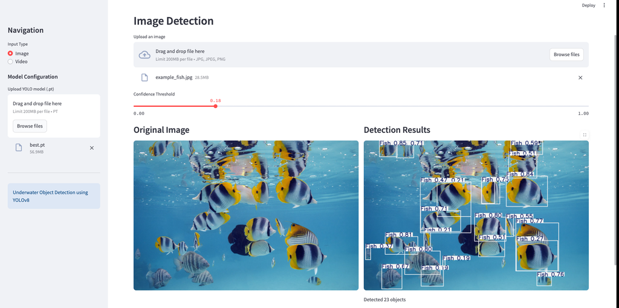